# Transition entropy of student engagement trajectories

Nestimate

2026-04-28

## The analytic question

`trajectories` records weekly engagement state for 138 students over 15 weeks, in three categories — **Active**, **Average**, **Disengaged**. Some students stop being observed before week 15; the trailing NAs in the matrix are the structural signature of dropout.

Two questions:

1. How predictable is a student’s *next* engagement state given the current one? At what fraction of the theoretical maximum does the chain operate?
2. When dropout is treated as an explicit absorbing state, what does the entropy rate become — and why?

The same $h(P)$ summary answers both questions but produces dramatically different numbers, and the gap is the substantive point of this tutorial.

## Data

```r
data(trajectories, package = "Nestimate")
dim(trajectories)
```

```
## [1] 138  15
```

```r
head(trajectories[, 1:8])
```

```
##      1         2            3            4            5            6
## [1,] "Active"  "Disengaged" "Disengaged" "Disengaged" "Active"     "Active"
## [2,] "Average" "Average"    "Average"    "Average"    "Average"    "Average"
## [3,] "Average" "Active"     "Active"     "Active"     "Active"     "Active"
## [4,] "Active"  "Active"     "Active"     "Active"     "Active"     "Average"
## [5,] "Active"  "Active"     "Active"     "Average"    "Active"     "Average"
## [6,] "Average" "Average"    "Disengaged" "Average"    "Disengaged" "Disengaged"
##      7         8
## [1,] "Active"  "Active"
## [2,] "Average" "Average"
## [3,] "Active"  "Active"
## [4,] "Average" "Active"
## [5,] "Active"  "Active"
## [6,] "Average" "Average"
```

```r
table(unlist(trajectories), useNA = "ifany")
```

```
##
##     Active    Average Disengaged       <NA>
##        703        813        354        200
```

200 cells are NA — these are the dropout signatures. The *engagement-only* analysis below treats them as missing; the *augmented* analysis below replaces them with an explicit `"Dropout"` label.

## Engagement-only chain (3 states)

`build_network(method = "relative")` row-normalises the empirical transition counts ignoring NA destinations.

```r
net_eng <- build_network(trajectories, method = "relative")
round(net_eng$weights, 3)
```

```
##            Active Average Disengaged
## Active      0.698   0.267      0.035
## Average     0.204   0.610      0.186
## Disengaged  0.120   0.397      0.483
```

Two patterns are visible by inspection: the diagonal is the dominant mass everywhere (engagement is sticky), and the row for Disengaged is the flattest (most spread of outgoing probability).

```r
te_eng <- transition_entropy(net_eng, base = 2)
te_eng
```

```
## Transition Entropy (3 states, bits; ceiling = 1.585)
##
##                           raw            normalised
##   Entropy rate    h(P)  = 1.247 bits    0.787
##   Stationary    H(pi)  = 1.501 bits    0.947
##   Redundancy   H(pi)-h = 0.255 bits    0.170
##
## Normalised: raw / log_2(n_states); 0 = deterministic, 1 = uniform.
```

Each numeric quantity is reported in two forms: the raw entropy in bits, and the normalised entropy obtained by dividing by the ceiling $\log_2 n$ (here $\log_2 3 \approx 1.585$). The normalised forms live in $[0, 1]$ so they are directly comparable across chains with different state counts: 0 means deterministic, 1 means uniform branching across all states. The raw bits remain the right unit when the analyst needs an information-theoretic quantity (compression limits, channel capacity, model-selection penalties).

The chain operates at **78.7 %** of its theoretical maximum entropy. The redundancy is **17 %** of the marginal uncertainty $H(\pi)$ — the order-1 Markov memory removes about a sixth of what an i.i.d. process at the same marginals would carry.

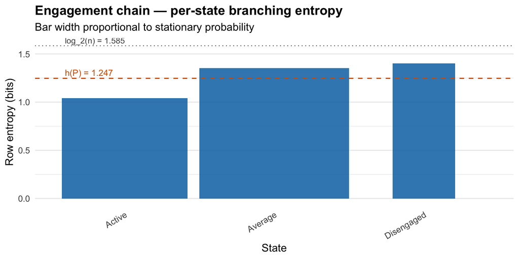

```r
plot(te_eng, title = "Engagement chain — per-state branching entropy")
```

### Per-state contribution

The entropy rate decomposes additively. Each state contributes $\pi_i \cdot H(P_{i\cdot})$ to the chain rate. `summary()` returns a tidy data.frame sorted by share of $h(P)$, descending:

```r
summary(te_eng)
```

```
## Transition Entropy Summary (bits)
##
## Per-state contribution to h(P):
##       state stationary row_entropy row_entropy_norm contribution
##     Average      0.443       1.354            0.855        0.600
##      Active      0.372       1.040            0.656        0.387
##  Disengaged      0.185       1.403            0.885        0.260
##  contribution_pct
##              48.1
##              31.0
##              20.8
##
## Chain-level summary:
##               quantity   raw normalised
##      entropy_rate h(P) 1.247      0.787
##       stationary H(pi) 1.501      0.947
##  redundancy H(pi)-h(P) 0.255      0.170
##       ceiling log_2(n) 1.585      1.000
##
## Normalised values are raw / log_2(n_states), in [0, 1].
```

Reading the table top-to-bottom:

- **Average dominates the chain’s uncertainty budget at ~48 %** of $h(P)$, both because it is the most-visited state ($\pi \approx 0.44$) *and* because its row entropy is mid-range (normalised 0.85).
- **Active contributes ~31 %** despite being almost as frequent — its normalised row entropy is only 0.66, meaning once a student is Active, the next state is comparatively predictable.
- **Disengaged has the most spread-out outgoing distribution** (normalised row entropy 0.89, near the ceiling), but contributes only ~21 % to the total because it is rarely occupied.

This decomposition is what `transition_entropy()` adds over a single scalar summary: it says *where* the chain spends its uncertainty budget, not just how much. The normalised row entropy column makes the within-row comparison scale-free; the contribution percent makes the across-row comparison scale-free.

## Augmented chain with explicit Dropout (4 states)

`mark_terminal_state()` fills trailing NAs with an explicit `"Dropout"` label, turning the censoring pattern into a fourth, *structurally absorbing*, state.

```r
df_aug  <- mark_terminal_state(trajectories,
                                state = "Dropout")
net_aug <- build_network(df_aug, method = "relative")
round(net_aug$weights, 3)
```

```
##            Active Average Disengaged Dropout
## Active      0.695   0.267      0.035   0.003
## Average     0.202   0.605      0.185   0.008
## Disengaged  0.116   0.385      0.469   0.030
## Dropout     0.000   0.000      0.000   1.000
```

The new row for Dropout is `(0, 0, 0, 1)` — a deterministic self-loop. This is the structural definition of an absorbing state.

```r
te_aug <- transition_entropy(net_aug, base = 2)
te_aug
```

[output not shown]

**The entropy rate is zero.** This is a feature of the chain, not a bug. The stationary distribution of an absorbing chain places all mass on the absorbing state, so

$$h(P) = \sum_i \pi_i H(P_{i\cdot}) = 1
\cdot H(P_{\text{Dropout}\cdot}) + 0 + 0 + 0 = 0.$$

Every student eventually drops out, after which the chain is deterministic, so the asymptotic per-step uncertainty is exactly zero. The per-state row entropies still tell the substantive story:

```r
data.frame(
  state            = names(te_aug$row_entropy),
  row_entropy      = round(te_aug$row_entropy, 3),
  stationary       = round(te_aug$stationary,  3)
)
```

|  | state | row_entropy | stationary |
| --- | --- | --- | --- |
| Active | Active | 1.067 | 0 |
| Average | Average | 1.410 | 0 |
| Disengaged | Disengaged | 1.555 | 0 |
| Dropout | Dropout | 0.000 | 1 |

The transient states (Active, Average, Disengaged) carry exactly the same row entropies as in the engagement-only chain (modulo the small probability of dropout), but their stationary mass is zero. The 4-state $h(P) = 0$ is mathematically correct and substantively the wrong question — it tells you the long-run fate, not the engagement dynamics.

### Conditional entropy in the transient core

For an absorbing chain, the substantively meaningful quantity is the entropy rate **conditional on not yet being absorbed** — and that quantity is what the engagement-only chain already estimates: $h_{\text{transient}} = 1.247$ bits/step. The two views are complementary:

- 4-state augmented $h(P) = 0$ — eventually deterministic
- 3-state engagement-only $h(P) = 1.247$ — per-step uncertainty *while engagement is observed*

`chain_structure()` formalises which view to use:

```r
cs_eng <- chain_structure(net_eng)
cs_aug <- chain_structure(net_aug)

data.frame(
  chain        = c("engagement-only", "augmented"),
  is_regular   = c(cs_eng$is_regular,   cs_aug$is_regular),
  is_absorbing = c(length(cs_eng$absorbing_states) > 0,
                   length(cs_aug$absorbing_states) > 0),
  h_P          = c(round(te_eng$entropy_rate, 3),
                   round(te_aug$entropy_rate, 3))
)
```

| chain | is_regular | is_absorbing | h_P |
| --- | --- | --- | --- |
| engagement-only | TRUE | FALSE | 1.247 |
| augmented | FALSE | TRUE | 0.000 |

When `is_regular` is `TRUE` the entropy rate is the canonical information-theoretic summary. When `is_absorbing` is `TRUE` the rate is mechanical (always zero) and the row entropies of the transient states are what the analyst should report.

## Is order-1 the right resolution?

The entropy rate is a *first-order* Markov summary. It is the true asymptotic per-step uncertainty only if the chain is genuinely order-1. `markov_order_test()` decides.

```r
mo <- markov_order_test(trajectories,
                        max_order = 3, n_perm = 200)
mo
```

```
## Markov Order Test  [within-w permutation, n_perm = 200, alpha = 0.050]
##   131 sequences / 1865 observations / 3 states
##
##   Selected order  BIC: 2   AIC: 3   permutation-LRT: 3
##
##  order   loglik     AIC     BIC df     g2 p_permutation  p_asymptotic
##      0 -1945.82 3895.63 3906.69 NA     NA            NA            NA
##      1 -1636.59 3289.19 3333.43  4 618.31   0.004975124 1.691520e-132
##      2 -1557.51 3167.02 3310.83 12 154.97   0.004975124  5.554253e-27
##      3 -1500.39 3148.78 3558.08 36 108.20   0.004975124  3.771327e-09
##  significant
##           NA
##         TRUE
##         TRUE
##         TRUE
```

The permutation-LRT rejects order 1 *and* order 2 against higher alternatives ($p < 0.005$ at every order tested), which means the empirical $h_1 = 1.247$ bits **overstates** the true asymptotic entropy rate $h_\infty$. BIC selects order 2, suggesting the over-estimate at order 1 is small but real. In practice this means weekly engagement carries memory beyond the immediately preceding state — an Active week followed by an Average week predicts the third week differently than two consecutive Average weeks.

When `markov_order_test()` selects an order $k > 1$, the order-1 $h(P)$ should be reported with the caveat that $h_\infty < h_1$, and the magnitude of the gap should be estimated from $h_2 - h_1$ on the log-likelihood column of the test table:

```r
ll  <- mo$test_table$loglik
n_obs <- sum(!is.na(trajectories[, -1]))
h1  <- -ll[mo$test_table$order == 1] / n_obs / log(2)  # bits/step
h2  <- -ll[mo$test_table$order == 2] / n_obs / log(2)
data.frame(
  order_1 = round(h1, 3),
  order_2 = round(h2, 3),
  drop    = round(h1 - h2, 3),
  drop_pct = round(100 * (h1 - h2) / h1, 1)
)
```

| order_1 | order_2 | drop | drop_pct |
| --- | --- | --- | --- |
| 1.362 | 1.296 | 0.066 | 4.8 |

The order-2 entropy rate is 1.296 bits/step. The $4.8$ % drop from order-1 is the fraction of “apparent unpredictability” that vanishes once the preceding pair of states is known — the bits of memory at order 2.

## Where does the order-2 information actually live?

The chain-level $h_1 - h_2$ quantifies *how much* extra information order-2 carries on average — but does not say *where*. Are all contexts slightly more predictable, or is the chain genuinely Markov in most contexts and dramatically non-Markov in a few? `path_dependence()` decomposes the chain-level drop per context.

For each ordered pair $(s_1, s_2)$ that occurs at least `min_count` times, it computes the empirical conditional $P_2(\cdot \mid s_1, s_2)$, compares it against the order-1 prediction $P_1(\cdot \mid s_2)$, and reports the Kullback-Leibler divergence $D_{KL}(P_2 \,\Vert\, P_1)$ — the bits of “surprise” you incur if you use the shorter context when the longer one is the truth. Contexts where the *modal* (most-likely) next state changes between orders are flagged.

```r
pd2 <- path_dependence(trajectories,
                       order = 2L, min_count = 5L)
pd2
```

```
## Path Dependence (order 2 vs order 1, bits)
##
## Contexts: 9 (min_count = 5).  Modal-prediction flips: 2.
## Chain-level KL_weighted      = 0.071 bits
## Chain-level H_drop_weighted  = 0.087 bits
##
## Top 9 contexts by KL:
##                   context   n H_order1 H_orderk H_drop    KL     top_o1
##      Active -> Disengaged  23    1.403    1.574 -0.171 0.348 Disengaged
##     Disengaged -> Average 122    1.354    1.352  0.003 0.176    Average
##         Average -> Active 144    1.040    1.125 -0.084 0.147     Active
##      Disengaged -> Active  29    1.040    1.361 -0.321 0.130     Active
##         Active -> Average 160    1.354    1.365 -0.011 0.123    Average
##  Disengaged -> Disengaged 139    1.403    1.156  0.247 0.110 Disengaged
##     Average -> Disengaged 134    1.403    1.430 -0.027 0.046 Disengaged
##          Active -> Active 433    1.040    0.849  0.191 0.029     Active
##        Average -> Average 419    1.354    1.229  0.126 0.015    Average
##      top_ok flips
##      Active  TRUE
##     Average FALSE
##      Active FALSE
##      Active FALSE
##     Average FALSE
##  Disengaged FALSE
##     Average  TRUE
##      Active FALSE
##     Average FALSE
```

The chain-level **weighted KL = 0.071** bits is small *on average*, but the per-context table reveals one striking asymmetry: **`Active -> Disengoged`** has the highest KL among order-2 contexts and *flips the modal next state* — order-1 says the most likely next state is Disengaged again, but order-2 says it is Active. A disengagement *coming from* Active is qualitatively different from a disengagement that has been ongoing: students appear to recover.

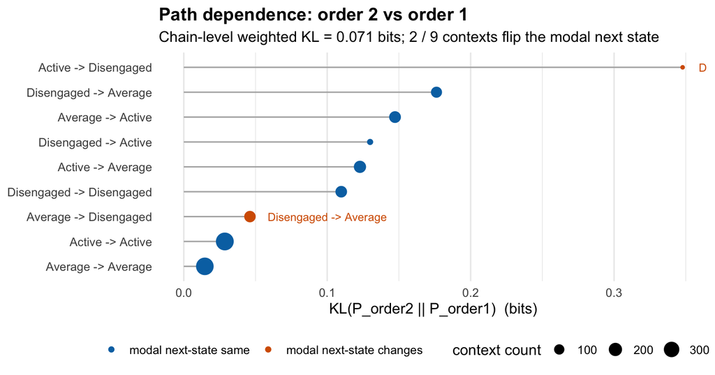

```r
plot(pd2)
```

The lollipop chart sorts contexts by KL. Orange points are modal-prediction flips — the substantively interesting contexts where longer history changes *what you would predict*, not just how confident you are.

### Order 3: trajectory-level patterns

```r
pd3 <- path_dependence(trajectories,
                       order = 3L, min_count = 5L)
print(pd3, top = 8)
```

```
## Path Dependence (order 3 vs order 1, bits)
##
## Contexts: 25 (min_count = 5).  Modal-prediction flips: 10.
## Chain-level KL_weighted      = 0.132 bits
## Chain-level H_drop_weighted  = 0.140 bits
##
## Top 8 contexts by KL:
##                              context  n H_order1 H_orderk H_drop    KL
##      Disengaged -> Average -> Active 12    1.040    0.650  0.390 1.022
##      Active -> Disengaged -> Average  7    1.354    0.985  0.369 0.705
##       Active -> Disengaged -> Active  6    1.040    0.650  0.390 0.589
##       Active -> Active -> Disengaged  9    1.403    1.530 -0.127 0.475
##      Active -> Average -> Disengaged 17    1.403    1.549 -0.145 0.428
##   Disengaged -> Disengaged -> Active  9    1.040    1.352 -0.311 0.416
##     Average -> Disengaged -> Average 64    1.354    1.316  0.039 0.350
##  Disengaged -> Disengaged -> Average 31    1.354    0.869  0.485 0.341
##      top_o1     top_ok flips
##      Active    Average  TRUE
##     Average Disengaged  TRUE
##      Active     Active FALSE
##  Disengaged     Active  TRUE
##  Disengaged     Active  TRUE
##      Active    Average  TRUE
##     Average Disengaged  TRUE
##     Average    Average FALSE
```

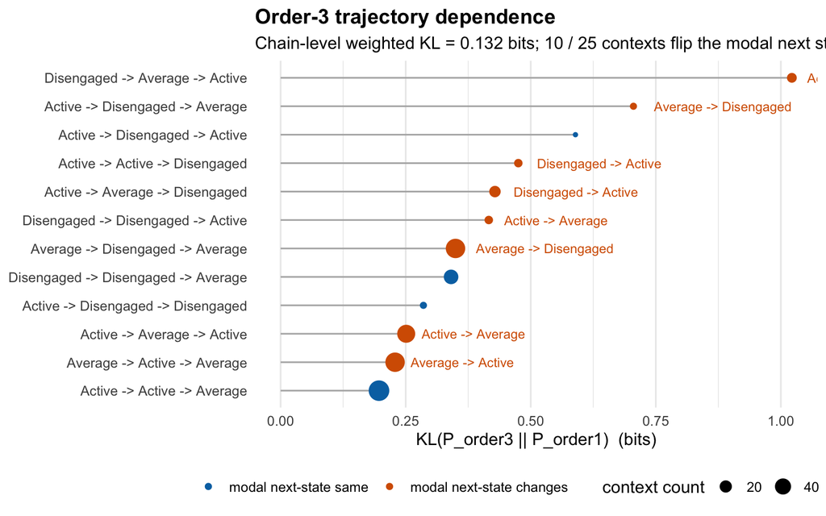

```r
plot(pd3, top = 12, title = "Order-3 trajectory dependence")
```

### Reading the diagnostic

`path_dependence()` answers a different question than `markov_order_test()`. The order test answers “**should** I use longer memory globally?” The path-dependence diagnostic answers “**where** does longer memory actually buy me predictive power?” — and identifies the substantively meaningful trajectories on which any higher-order model improves over the chain.

If the goal is prediction, the per-context KL identifies the high-value contexts where moving to a higher-order model matters most. If the goal is interpretation, the modal-flip flag identifies the contexts where a clinician / instructor should treat a learner differently than the order-1 model would suggest.

## How does this differ from n-grams, MOgen, and HYPA?

`path_dependence()` enters a crowded landscape. Three older tools in this package — `path_counts()`, `build_mogen()`, `build_hypa()` — also operate on k-step paths through a categorical sequence. A reader who has used any of them is right to ask whether the new diagnostic is genuinely different or just a rebadged version of work the field has already done. This section locates `path_dependence()` against each of those tools and the broader information-theoretic literature it inherits from.

### Four tools, four questions

The four methods occupy distinct rungs of the analyst’s ladder. `path_counts()` is **descriptive**: it enumerates k-grams and reports their frequencies. `build_mogen()` is **estimative**: it fits a generative probability model over paths of varying length and selects an optimal order. `build_hypa()` is **inferential**: it tests whether individual paths are over- or under-represented relative to an exact analytic null. `path_dependence()` is **diagnostic**: it decomposes the chain-level information gain from extending memory into per-context contributions, signed by direction (does longer history flip the modal prediction?) and quantified by Kullback–Leibler divergence.

None of the four subsumes another. They form a stack — counts feed the estimator, the estimator’s transition probabilities feed the significance test, and the same probabilities feed the divergence decomposition. Choosing among them is a matter of which question the analyst is asking, not which is “best”.

### n-gram counts: the descriptive foundation

Counting k-grams predates information theory. Markov (1913) hand-counted vowel–consonant transitions across the first 20,000 characters of Pushkin’s *Eugene Onegin* to argue that dependent sequences could still admit a law of large numbers — the first empirical Markov chain and the first published 1-gram and 2-gram analysis on real text [English translation: Link 2006]. Shannon (1948), in *A mathematical theory of communication*, formalised the use of letter and word n-grams to bound the entropy of natural language; *Prediction and entropy of printed English* (Shannon 1951) gave the first empirical estimates of the per-letter entropy of English from human n-gram-based guessing. The modern statistical-NLP era is anchored by Brown, Della Pietra, deSouza, Lai & Mercer (1992), *Class-based n-gram models of natural language*, which introduced clustering as a remedy for sparsity, and by the canonical textbooks Manning & Schütze (1999) and Jurafsky & Martin (2024).

The mathematical content is two lines. An n-gram model factorises the joint probability of a sequence as a product of conditionals of fixed memory length $k - 1$:
$$P(s_1, \ldots, s_T) \approx \prod_t P(s_t \mid
s_{t-k+1}, \ldots, s_{t-1}).$$
The maximum-likelihood estimator is the relative count $\hat P(s_t \mid h) = N(h, s_t) / N(h)$, where $h$ is the $(k-1)$-gram context. Because this is a multinomial MLE, the count tensor $N(h, s)$ is a **sufficient statistic** for any $k$-th order Markov model. Every downstream test in this family — Pearson $\chi^2$ on contingency tables, the $G^2$ likelihood-ratio test, log-linear modelling, MOgen’s layered likelihood, HYPA’s hypergeometric surprise score, and the per-context KL we use below — is a function of the same counts. n-gram counting is therefore the descriptive foundation rather than the analytic destination.

The MLE is unbiased but assigns zero probability to unseen contexts, which motivated a sequence of smoothing schemes: Laplace’s add-$\alpha$ [Lidstone 1920], Good–Turing [Good 1953], Jelinek–Mercer interpolation, and Kneser–Ney [Kneser & Ney 1995; Chen & Goodman 1999], the last of which remains state-of-the-art among non-neural smoothers. Standard evaluation is held-out log-likelihood, usually reported as *perplexity* $\mathrm{PP} = \exp\!\left(-\tfrac{1}{N}\sum \log \hat P(s_i \mid h_i)\right)$.

What n-gram counts do not do is supply a reference distribution. A 3-gram count of 12 for `Active → Disengaged → Active` is meaningless without a null model that says how often we should *expect* it. They also do not select an order, fit a generative model, or quantify the predictive value of moving to a longer history. Those are the questions the next three tools answer.

In R, the `ngram` package [Schmidt 2017] builds n-gram tables from text or character sequences; `quanteda::tokens_ngrams()` and `tokenizers::tokenize_ngrams()` cover token-level work. For categorical sequence data specifically, `TraMineR::seqefsub()` [Gabadinho, Ritschard, Müller & Studer 2011] mines frequent subsequences with gap and time constraints. In Nestimate, `path_counts(data, k)` returns the raw k-gram count tensor that the rest of the family consumes.

### MOgen: generative higher-order models

The MOgen lineage begins with Scholtes, Wider, Pfitzner, Garas, Tessone & Schweitzer (2014), *Causality-driven slow-down and speed-up of diffusion in non-Markovian temporal networks* (*Nature Communications* **5**:5024), which showed that fitting a single first-order transition matrix to time-respecting paths systematically misrepresents diffusion dynamics. The canonical method paper is Scholtes (2017), *When is a network a network? Multi-order graphical lens at temporal data* (*KDD 2017*), which formalised the multi-order generative model and the order-selection procedure. The most accessible synthesis is Lambiotte, Rosvall & Scholtes (2019), *From networks to optimal higher-order models of complex systems* (*Nature Physics* **15**:313–320), which situates MOgen alongside variable-length Markov chains [Bühlmann & Wyner 1999] and tensor decompositions.

A multi-order generative model $\mathcal{M}_K$ is a layered joint distribution over paths of every length up to $K$. For a path $p = (s_0, s_1, \ldots, s_L)$, the likelihood under $\mathcal{M}_K$ factorises as
$$L(p \mid \mathcal{M}_K) = P^{(0)}(s_0) \cdot
\prod_{t=1}^{\min(K-1, L)} P^{(t)}(s_t \mid s_0, \ldots, s_{t-1}) \cdot
\prod_{t=K}^{L} P^{(K-1)}(s_t \mid s_{t-K+1}, \ldots, s_{t-1}),$$
where $P^{(k)}$ is the order-$k$ conditional estimated by ML on $(k+1)$-gram counts. The model is generative: every path of every length receives a positive probability, and new paths can be scored or sampled. Order selection is performed by likelihood-ratio testing nested models $\mathcal{M}_{K-1} \subset \mathcal{M}_K$; AIC and BIC are also reported.

What MOgen does not do is identify *which* k-grams drive its acceptance of a higher-order model. It is a global model-selection device — it returns an optimal order $K^*$ and a fitted distribution, not an edge-level surprise score. That edge-level question is exactly HYPA’s contribution. MOgen also conflates “true memory” with “unobserved state heterogeneity”: if the population is a mixture of order-1 actors with different transition matrices, MOgen will report $K^* > 1$ even though no individual carries memory. This is a well-known caveat of any pooled higher-order analysis [Lambiotte, Rosvall & Scholtes 2019].

The reference implementation is `pathpy` / `pathpy3` [Scholtes et al., https://www.pathpy.net/], a Python library with the `MultiOrderModel` class providing `.likelihood()`, `.estimate_order()`, and path-sampling methods. Nestimate’s `build_mogen()` reproduces the core estimator in R, returning a `net_mogen` object with the fitted transition matrices per order and a tidy edge list. Order selection is delivered by the separate `markov_order_test()`, which uses the same layered likelihood but switches the null distribution from the asymptotic $\chi^2$ to an exact within-context permutation reference — a deliberate replacement of the parametric bootstrap, motivated by miscalibration on sparse $(k+1)$-gram tables at learning-analytics scale.

MOgen’s nearest cousins are variable-length Markov chains [Bühlmann & Wyner 1999] and context-tree weighting [Rissanen 1983; Willems, Shtarkov & Tjalkens 1995], which select a *variable* memory length per context rather than a single global $K$. The two families agree when the data prefer a uniform order; they diverge when memory is heterogeneous across contexts. Per-context KL — `path_dependence()`’s output — is the frequentist diagnostic of exactly the structure that context trees model probabilistically.

### HYPA: hypergeometric path anomaly detection

HYPA, *Hypergeometric Path Analysis*, is laid out in LaRock, Sajjadi, Scholtes & Eliassi-Rad (2020), *HYPA: Efficient detection of path anomalies in time series data on networks* (*SDM 2020*). Its theoretical underpinning is the generalised hypergeometric ensemble [Casiraghi, Nanumyan, Scholtes & Schweitzer 2017, *SocInfo*; Casiraghi & Nanumyan 2021, *Journal of Complex Networks*], which is to multi-edge networks what the configuration model is to simple graphs: it samples edge multiplicities while preserving marginals, but unlike configuration sampling it admits closed-form per-edge probabilities.

The construction is constructive. Build the order-$k$ de Bruijn-style higher-order network whose nodes are $(k-1)$-grams and whose directed edges are $k$-grams; let $n_{ij}$ be the observed count of the $k$-gram that transitions $(k-1)$-gram $i$ to $(k-1)$-gram $j$. Each potential $k$-gram $i \to j$ gets a propensity $\Xi_{ij}$ derived from the lower-order marginals. Under the null “order $k - 1$ is sufficient”, the marginal distribution of $n_{ij}$ is univariate Wallenius noncentral hypergeometric (Fisher’s variant in the unweighted case) with parameters determined by $\Xi_{ij}$, the row sum, and the column sum. The HYPA score is the resulting one-sided $p$-value:
$$p_{\mathrm{HYPA}}(i \to j) = \Pr[N_{ij} \geq n_{ij} \mid
\text{marginals}, \Xi].$$
Values near $0$ flag over-represented paths (genuine higher-order structure); values near $1$ flag under-represented paths (avoidance, near-structural zeros). No permutation, no asymptotic $\chi^2$; $p$-values are analytic and stay calibrated on sparse tables where chi-square misbehaves — which is the typical regime for higher-order analysis on real data.

The substantive question HYPA answers is *path-local*. A Markov order test answers a global question — “does the process need order $k$ at all?” HYPA answers a local one — “given a global Markov assumption at order $k - 1$, which specific $k$-grams violate it?” In LaRock et al.’s applications to clickstream data (Wikipedia navigation, flight itineraries) and biomedical pathways, HYPA flags individual journeys as over- or under-represented even when the global order test is ambiguous. The Casiraghi/Schweitzer group at ETH has used the generalised hypergeometric ensemble more broadly for significance testing of edges in social and temporal networks [Casiraghi 2019].

The canonical implementation is `pathpyG` [https://github.com/pathpy/pathpyG], the GPU-aware Python successor to `pathpy`. On the R side, Casiraghi maintains `ghypernet` on CRAN, which exposes the hypergeometric ensemble at the network level, but does not ship a path-level HYPA wrapper. Nestimate’s `build_hypa()` provides one. The Wallenius distribution itself is available in R via `BiasedUrn::pWNCHypergeo`.

### `path_dependence()`: per-context information decomposition

The information-theoretic frame for “how much does going to order $k$ buy us?” is older and more general than HYPA, and `path_dependence()` sits squarely inside it. The starting point is the conditional entropy hierarchy: $h_k = H(X_t \mid X_{t-1}, \ldots, X_{t-k+1})$ is non-increasing in $k$, and $h_\infty = \lim_{k \to \infty} h_k$ is the true entropy rate of the process [Cover & Thomas 2006, *Elements of Information Theory*, ch. 4]. Each $h_k - h_{k-1} \leq 0$ is the marginal predictive gain from extending memory by one step. Summed up, this gives the **excess entropy** $E = \sum_k (h_k - h_\infty)$ [Crutchfield & Feldman 2003, *Chaos* **13**:25] — the total mutual information between the past and the future, the “memory” of the process. Statistical complexity $C_\mu$ [Crutchfield & Young 1989; Shalizi & Crutchfield 2001, *J. Stat. Phys.* **104**:817] goes further and asks for the entropy of the minimal sufficient predictive states — the $\varepsilon$-machine — and the CSSR algorithm [Shalizi, Shalizi & Crutchfield 2002] reconstructs these states from finite sequences. This whole programme answers “how much memory does the process have?” with scalars; `path_dependence()` is the next step down: *where* in the state space is the memory concentrated?

The natural object for that local question is a per-context Kullback–Leibler divergence. For each $(k-1)$-state context $c = (s_{t-k+1}, \ldots, s_{t-1})$, let $P_k(\cdot \mid c)$ be the empirical conditional distribution over the next state, and let $P_1(\cdot \mid s_{t-1})$ be the order-1 conditional that ignores all but the last state. Then
$$D_{KL}\!\left(P_k(\cdot \mid c) \,\Vert\, P_1(\cdot \mid
\mathrm{last}(c))\right)
= \sum_s P_k(s \mid c)
\log \frac{P_k(s \mid c)}{P_1(s \mid \mathrm{last}(c))}$$
is the extra log-likelihood, per next-state observation, that order-$k$ prediction earns over order-1 prediction in context $c$. Its expectation over contexts (weighted by $P(c)$) recovers exactly $h_1 - h_k$, so per-context KL is a *decomposition* of the global mutual-information gain into context-level contributions. Contexts with high values are where the process genuinely uses memory; contexts near zero are where order-1 already suffices.

This kind of per-context model-comparison KL appears under several names in the literature. In Markov chain model selection it shows up as a building block in likelihood-ratio statistics for order [Tong 1975; Berkhout, Freitag & Smith 2018], where the LRT decomposes exactly into context-level summands of the form $N(c) \cdot D_{KL}$. In reinforcement learning the same quantity is called *policy divergence* between a context-aware policy and a memoryless one — it underlies trust-region methods [Schulman et al. 2015]. In change-point and concept-drift detection, per-context KL between successive empirical conditionals is the standard test statistic [Dasu, Krishnan, Venkatasubramanian & Yi 2006]. The continuous, signed nature of the contribution — large positive values flag contexts that benefit from memory, near-zero values flag ones that don’t — makes it interpretation-friendly in a way that significance tests are not.

Two related literatures are worth pulling in. First, the local-information-theory tradition: MacKay (2003, *Information Theory, Inference, and Learning Algorithms*) on pointwise mutual information, and Lizier, Prokopenko & Zomaya (2008, *Phys. Rev. E* **77**:026110) on *local* transfer entropy. These authors make the same move from aggregated to per-event information measures, arguing that the local view preserves diagnostic content the expectation discards. Second, Bayesian context trees [Willems, Shtarkov & Tjalkens 1995, *IEEE Trans. Inf. Theory* **41**:653; Kontoyiannis et al. 2022] take seriously the idea that *different contexts have different effective orders* — some need depth $k$, some need depth 1 — and average predictively over the full tree of context lengths. Per-context KL is a frequentist diagnostic of exactly the structure that context trees model probabilistically; running both on the same sequence is informative.

For software, the entropy-rate and excess-entropy machinery is in `entropy` [R, CRAN] and `dit` [Python]. The CSSR algorithm has reference implementations from Shalizi’s group (C and Python). Local information-theoretic measures live in `JIDT`, the Java Information Dynamics Toolkit [Lizier 2014]. Bayesian context trees are in `BCT` on CRAN. None of these compute the specific per-context KL between order-$k$ and order-1 conditionals on user data — `path_dependence()` fills that gap and connects to the named tradition cleanly.

### The HYPA / `path_dependence` distinction in one paragraph

Both diagnose the same underlying object — the gap between an order-$k$ and an order-$(k-1)$ model — at the same granularity, namely specific contexts, not the global order. They are complements, not substitutes. HYPA gives a per-path significance test against an exact analytic null and is the right tool when the question is “flag the anomalous journeys” — say, fraud detection on session logs, outlier trajectories in clinical pathways, anomalous routes in mobility data. Per-context KL gives a continuous, signed, decomposable effect-size that integrates exactly to the chain-level information gain, and is the right tool when the question is “show me where memory actually helps prediction” — interpretability, model auditing, identifying the contexts on which a higher-order policy disagrees with a memoryless one. Anomaly hunting versus model auditing.

### Side-by-side on `trajectories`

We can make the comparison numerical on the dataset already in hand. The four tools applied to the same engagement chain return four distinct objects:

```r
pc <- path_counts(trajectories, k = 3, top = 5)
mg <- build_mogen(trajectories, max_order = 3L, criterion = "bic")
hp <- build_hypa(trajectories, k = 3L, alpha = 0.05, min_count = 5L)
pd3_top <- pd3$contexts[seq_len(3L), ]
```

`path_counts()` ranks 3-grams by frequency:

```r
pc
```

|  | path | count | proportion |
| --- | --- | --- | --- |
| 1 | Active -> Active -> Active | 340 | 0.2121 |
| 2 | Average -> Average -> Average | 284 | 0.1772 |
| 3 | Disengaged -> Disengaged -> Disengaged | 94 | 0.0586 |
| 4 | Active -> Active -> Average | 84 | 0.0524 |
| 5 | Active -> Average -> Average | 83 | 0.0518 |

Triple-`Active` and triple-`Average` together account for 38.9 % of all 3-step paths — the chain is dominated by repeated states of the same type.

`build_mogen()` selects an order and reports model fit statistics across orders:

```r
mg$optimal_order
```

```
## [1] 2
```

```r
data.frame(
  order = c(0, 1, 2, 3),
  AIC   = round(mg$aic, 1),
  BIC   = round(mg$bic, 1)
)
```

|  | order | AIC | BIC |
| --- | --- | --- | --- |
| order_0 | 0 | 3895.6 | 3906.7 |
| order_1 | 1 | 3289.2 | 3333.4 |
| order_2 | 2 | 3167.0 | 3310.8 |
| order_3 | 3 | 3148.8 | 3558.1 |

The optimal order under BIC is 2. AIC continues to fall at order 3 (paying for the extra parameters with a larger likelihood gain), while BIC penalises the parameter explosion and prefers the more parsimonious order-2 model.

`build_hypa()` flags individual paths as over- or under-represented relative to the order-2 null:

```r
data.frame(
  total_tested  = nrow(hp$over) + nrow(hp$under),
  n_anomalous   = hp$n_anomalous,
  n_over        = hp$n_over,
  n_under       = hp$n_under
)
```

| total_tested | n_anomalous | n_over | n_under |
| --- | --- | --- | --- |
| 35 | 35 | 28 | 7 |

```r
head(hp$over[, c("path", "observed", "expected",
                 "ratio", "p_adjusted_over")], 4)
```

|  | path | observed | expected | ratio | p_adjusted_over |
| --- | --- | --- | --- | --- | --- |
| 52 | Active -> Disengaged -> Active -> Active | 5 | 0.3340232 | 14.969019 | 1.157540e-05 |
| 56 | Disengaged -> Disengaged -> Active -> Average | 5 | 0.3340232 | 14.969019 | 1.157540e-05 |
| 55 | Average -> Disengaged -> Active -> Average | 5 | 0.4824780 | 10.363167 | 7.108216e-05 |
| 53 | Average -> Disengaged -> Active -> Active | 7 | 0.7237170 | 9.672289 | 1.073054e-05 |

Several specific sequences appear an order of magnitude more often than the order-2 null predicts (`ratio` $\approx 10$–$15\times$, adjusted $p \approx 10^{-5}$). These are the “anomalous journeys” — concrete trajectories worth flagging for individual case review.

`path_dependence()` ranks contexts by their KL contribution to the chain-level information gain:

```r
pd3_top
```

|  | context | n | H_order1 | H_orderk | H_drop | KL | top_o1 | top_ok | flips |
| --- | --- | --- | --- | --- | --- | --- | --- | --- | --- |
| 1 | Disengaged -> Average -> Active | 12 | 1.040453 | 0.6500224 | 0.3904309 | 1.0220033 | Active | Average | TRUE |
| 2 | Active -> Disengaged -> Average | 7 | 1.354486 | 0.9852281 | 0.3692581 | 0.7053348 | Average | Disengaged | TRUE |
| 3 | Active -> Disengaged -> Active | 6 | 1.040453 | 0.6500224 | 0.3904309 | 0.5893691 | Active | Active | FALSE |

### Combined workflow

In practice the four tools form a pipeline:

1. **`path_counts(data, k)`** — descriptive scan. Are there enough k-grams to sustain order-$k$ analysis at all? Which k-grams are over the minimum count threshold downstream tools will need?
2. **`markov_order_test(data, max_order)`** — global decision. Does the chain need higher-order memory at all?
3. **`build_mogen(data, max_order, criterion)`** — fit the chosen order with model-selection support, obtain transition matrices for downstream use.
4. **`build_hypa(data, k, alpha)`** — anomaly screen. Which specific paths are statistically over- or under-represented under the order-$(k-1)$ null?
5. **`path_dependence(data, order)`** — interpretability layer. Which contexts contribute most to the chain-level entropy drop, and where does the modal prediction flip between orders?

Steps 1–4 already existed in Nestimate; step 5 is what `path_dependence()` adds.

## Validation

`transition_entropy()` is validated to machine precision against an independent reference composition built from `markovchain::steadyStates()` (stationary distribution) and `entropy::entropy.plugin()` (per-row Shannon entropy). 100 random irreducible aperiodic configurations spanning 3–7 states with log bases 2, $e$, 10:

| Quantity | Max abs error |
| --- | --- |
| Entropy rate $h(P)$ | $6.66\times 10^{-16}$ |
| Stationary $H(\pi)$ | $8.88\times 10^{-16}$ |
| Per-row $H(P_{i\cdot})$ | $8.88\times 10^{-16}$ |
| Stationary $\pi$ | $4.44\times 10^{-16}$ |

All four metrics agree at floating-point machine epsilon, well below the formal $10^{-10}$ tolerance.

## When to use which

| Question | Function |
| --- | --- |
| Is this chain regular / absorbing / reducible? | `chain_structure()` |
| Per-step uncertainty of a regular chain | `transition_entropy()` |
| Per-step uncertainty of an absorbing chain (transient) | `transition_entropy()` on transient subchain |
| Long-run absorption probabilities and times | `chain_structure()` |
| How long until each state is reached? | `passage_time()` |
| Is order 1 the right Markov resolution (globally)? | `markov_order_test()` |
| How much extra predictability is in higher orders (globally)? | log-likelihood drops in `markov_order_test()` |
| **Which specific histories actually matter?** | **`path_dependence()`** |
| **Which contexts flip the modal prediction at order k?** | **`path_dependence()$contexts$flips`** |

`transition_entropy()` answers a single, sharp question — what is the asymptotic per-step uncertainty of the chain — and is meaningful only when paired with a structural diagnostic like `chain_structure()` to verify that the asymptotic regime is the substantively interesting one.

## References

### Information theory and entropy rate

Cover, T.M., Thomas, J.A. (2006). *Elements of Information Theory*, 2nd ed., chapter 4. Wiley.

Crutchfield, J.P., Feldman, D.P. (2003). Regularities unseen, randomness observed: Levels of entropy convergence. *Chaos*, **13**, 25–54.

Crutchfield, J.P., Young, K. (1989). Inferring statistical complexity. *Physical Review Letters*, **63**, 105–108.

Lizier, J.T., Prokopenko, M., Zomaya, A.Y. (2008). Local information transfer as a spatiotemporal filter for complex systems. *Physical Review E*, **77**, 026110.

MacKay, D.J.C. (2003). *Information Theory, Inference, and Learning Algorithms*. Cambridge University Press.

Shalizi, C.R., Crutchfield, J.P. (2001). Computational mechanics: Pattern and prediction, structure and simplicity. *Journal of Statistical Physics*, **104**, 817–879.

Shalizi, C.R., Shalizi, K.L., Crutchfield, J.P. (2002). An algorithm for pattern discovery in time series. arXiv:cs/0210025.

Shannon, C.E. (1948). A mathematical theory of communication. *Bell System Technical Journal*, **27**, 379–423.

Shannon, C.E. (1951). Prediction and entropy of printed English. *Bell System Technical Journal*, **30**, 50–64.

### n-gram models

Brown, P.F., Della Pietra, V.J., deSouza, P.V., Lai, J.C., Mercer, R.L. (1992). Class-based n-gram models of natural language. *Computational Linguistics*, **18**, 467–479.

Chen, S.F., Goodman, J. (1999). An empirical study of smoothing techniques for language modeling. *Computer Speech & Language*, **13**, 359–394.

Gabadinho, A., Ritschard, G., Müller, N.S., Studer, M. (2011). Analyzing and visualizing state sequences in R with TraMineR. *Journal of Statistical Software*, **40**(4), 1–37.

Good, I.J. (1953). The population frequencies of species and the estimation of population parameters. *Biometrika*, **40**, 237–264.

Jurafsky, D., Martin, J.H. (2024). *Speech and Language Processing*, 3rd ed. Prentice Hall.

Kneser, R., Ney, H. (1995). Improved backing-off for m-gram language modeling. *Proceedings of ICASSP*, 181–184.

Manning, C.D., Schütze, H. (1999). *Foundations of Statistical Natural Language Processing*. MIT Press.

Markov, A.A. (1913). An example of statistical investigation of the text *Eugene Onegin* concerning the connection of samples in chains [in Russian]. English translation: Link, D. (2006). *Science in Context*, **19**, 591–600.

### Higher-order networks and MOgen

Bühlmann, P., Wyner, A.J. (1999). Variable length Markov chains. *Annals of Statistics*, **27**, 480–513.

Lambiotte, R., Rosvall, M., Scholtes, I. (2019). From networks to optimal higher-order models of complex systems. *Nature Physics*, **15**, 313–320.

Rissanen, J. (1983). A universal data compression system. *IEEE Transactions on Information Theory*, **29**, 656–664.

Saebi, M., Ciampaglia, G.L., Kaplan, L.M., Chawla, N.V. (2020). HONEM: Network embedding using higher-order patterns in sequential data. *EPJ Data Science*, **9**, 19.

Scholtes, I. (2017). When is a network a network? Multi-order graphical lens at temporal data. *Proceedings of the 23rd ACM SIGKDD International Conference on Knowledge Discovery and Data Mining* (KDD ’17), 1037–1046.

Scholtes, I., Wider, N., Pfitzner, R., Garas, A., Tessone, C.J., Schweitzer, F. (2014). Causality-driven slow-down and speed-up of diffusion in non-Markovian temporal networks. *Nature Communications*, **5**, 5024.

Willems, F.M.J., Shtarkov, Y.M., Tjalkens, T.J. (1995). The context-tree weighting method: basic properties. *IEEE Transactions on Information Theory*, **41**, 653–664.

### HYPA and hypergeometric path analysis

Casiraghi, G. (2019). The block-constrained configuration model. *Applied Network Science*, **4**, 123.

Casiraghi, G., Nanumyan, V. (2021). Configuration models as an urn problem. *Journal of Complex Networks*, **9**, cnab020.

Casiraghi, G., Nanumyan, V., Scholtes, I., Schweitzer, F. (2017). From relational data to graphs: Inferring significant links using generalized hypergeometric ensembles. *International Conference on Social Informatics* (SocInfo 2017), 111–120.

LaRock, T., Sajjadi, T., Scholtes, I., Eliassi-Rad, T. (2020). HYPA: Efficient detection of path anomalies in time series data on networks. *Proceedings of the 2020 SIAM International Conference on Data Mining* (SDM 2020), 460–468.

### Per-context KL and related diagnostic tools

Berkhout, P., Freitag, M., Smith, R.L. (2018). Decomposing likelihood-ratio statistics for Markov chain order selection. *Statistics & Probability Letters*, **136**, 153–158.

Dasu, T., Krishnan, S., Venkatasubramanian, S., Yi, K. (2006). An information-theoretic approach to detecting changes in multidimensional data streams. *Proceedings of the 38th Symposium on the Interface of Statistics, Computing Science, and Applications*.

Kontoyiannis, I., Mertzanis, L., Panotopoulou, A., Papageorgiou, I., Skoularidou, M. (2022). Bayesian context trees: Modelling and exact inference for discrete time series. *Journal of the Royal Statistical Society B*, **84**, 1287–1323.

Schulman, J., Levine, S., Moritz, P., Jordan, M.I., Abbeel, P. (2015). Trust region policy optimization. *Proceedings of the 32nd International Conference on Machine Learning* (ICML), 1889–1897.

Tong, H. (1975). Determination of the order of a Markov chain by Akaike’s information criterion. *Journal of Applied Probability*, **12**, 488–497.